# R Intermediate 2: Functional programming

Andrew Moles

Learning Developer, Digital Skills Lab

05 October, 2023

# Objective of workshop

To start using functional programming techniques, with the apply and map family of functions, to perform iteration.

# What this workshop will cover

In this workshop, the aim is to cover how to start working with apply and map functions in R. This will primarily include:

- Perform rowwise and columnwise operations with `apply()`
- Using the lapply, sapply, and vapply functions to perform iteration
- Using apply functions to load in lots of data
- Perform aggregation with tapply
- Start using map family of functions and compare use to apply

# Why do we need apply functions? And what are they?

For loops can be complicated and difficult to write. Luckily, you don’t always have to write them in R thanks to its functional nature. Someone else has written these loops and put them into a function! This is known as *functional programming*.

> Of course, someone has to write loops. It doesn’t have to be you. — Jenny Bryan

Jenny Bryan is a software developer as RStudio: https://jennybryan.org/

There are two main options when it comes to using *functional loops* in R, the apply family of functions, and the map family of functions. This workshop will go through both!

# Introduction to the apply family of functions

The apply family of functions eliminate common uses of the for loop in R and are part of the reason for loops are not seen as often in the R programming language compared to a language like Python. They simplify the process so it can be written in more concisely, often just one line of code.

There are five common apply functions:

- `apply()` allows you to select your *margins* to decide if you want to work rowwise or columnwise
- `lapply()` outputs lists and only works columnwise
- `sapply()` is similar to lapply but will return a vector
- `vapply()` is similar to lapply and sapply but you need to specify outcome data type
- `tapply()` breaks a vector into segments then applies a function to those segments

There are other apply functions, such as mapply, that are beyond the scope of this tutorial to cover. Knowledge of how to use apply will enable you to be able to use the other apply functions.

We will begin with the `apply()` function. The apply function can perform iterations across rows or columns. You decide this by adding either 1 or 2 into the `MARGIN` parameter. We select 1 to work across on rows, and 2 to work across on columns.

The syntax for apply by default takes three arguments: the data, which margin (rowwise or columnwise) and the function you want to perform. If the function you are using needs to use a parameter ,like na.rm = TRUE, then you add that after a comma `apply(data, MARGIN = 1 or 2, function, function parameter)`.

To demonstrate, we will use the palmers penguins dataset. If you are running code in this example you will need to install the palmerpenguins library where the data is held.

```r
install.packages("palmerpenguins")
```

The palmer penguins data were collected and made available by [Dr. Kristen Gorman](https://www.uaf.edu/cfos/people/faculty/detail/kristen-gorman.php) and the [Palmer Station, Antarctica LTER](https://pal.lternet.edu/), a member of the [Long Term Ecological Research Network](https://lternet.edu/).

There are two datasets, we will just look at the cleaned up *penguins* data.

```r
# load library
library(palmerpenguins)
# load data to environment
data(penguins)
# review data
head(penguins)
```

```
## # A tibble: 6 × 8
##   species island    bill_length_mm bill_depth_mm flipper_length_mm body_mass_g
##   <fct>   <fct>              <dbl>         <dbl>             <int>       <int>
## 1 Adelie  Torgersen           39.1          18.7               181        3750
## 2 Adelie  Torgersen           39.5          17.4               186        3800
## 3 Adelie  Torgersen           40.3          18                 195        3250
## 4 Adelie  Torgersen           NA            NA                  NA          NA
## 5 Adelie  Torgersen           36.7          19.3               193        3450
## 6 Adelie  Torgersen           39.3          20.6               190        3650
## # ℹ 2 more variables: sex <fct>, year <int>
```

## How to “apply” (rowwise)

Working across rows is often called working *rowwise*. By working *rowwise* we can perform a calculation or a function across several columns for each row.

For example, in the penguins data we might want to find the average of the three columns bill_length_mm, bill_depth_mm and flipper_length_mm for each row of data we have.

Notice what happens when you run the below chunk. Take a moment to work through each component of the syntax to understand the iterative process.

```r
columns <- c("bill_length_mm", "bill_depth_mm", "flipper_length_mm")
apply_rows <- apply(penguins[ , columns], MARGIN = 1, mean, na.rm = TRUE)

# print first 5
apply_rows[1:5]
```

```
## [1] 79.60000 80.96667 84.43333      NaN 83.00000
```

This technique is most useful if we were to add that data back into the data frame, making a new column with our averages. This can be really useful if you are working with survey data and need to calculate the sum or average of questions for each participant in your survey. Check example below!

```r
penguins$bill_flip_avg <- apply(penguins[ ,columns], MARGIN = 1, mean, na.rm = TRUE)

# view data frame with added column
penguins[1:5, c("bill_length_mm", "bill_depth_mm",
                "flipper_length_mm", "bill_flip_avg")]
```

```
## # A tibble: 5 × 4
##   bill_length_mm bill_depth_mm flipper_length_mm bill_flip_avg
##            <dbl>         <dbl>             <int>         <dbl>
## 1           39.1          18.7               181          79.6
## 2           39.5          17.4               186          81.0
## 3           40.3          18                 195          84.4
## 4           NA            NA                  NA         NaN
## 5           36.7          19.3               193          83
```

Another option to doing rowwise calculations are to use the rowMeans or rowSums functions that come with R by default. They perform rowwise calculations faster than apply, but are limited to mean or sum calculations.

```r
# mean of cols for first 5 rows
rowMeans(penguins[1:5 , columns], na.rm = TRUE)
```

```
## [1] 79.60000 80.96667 84.43333      NaN 83.00000
```

```r
# sum of cols for first 5 rows
rowSums(penguins[1:5 , columns], na.rm = TRUE)
```

```
## [1] 238.8 242.9 253.3   0.0 249.0
```

Other calculations such as min, max, interquartile range are available with the `matrixStats` package.

### Rowwise apply exercise

This this exercise we will use [song data from Spotify](https://github.com/rfordatascience/tidytuesday/blob/master/data/2020/2020-01-21/readme.md). The dataset has information such as artist, popularity, and information about the song such as *danceability*.

Using the code provided:

1. Review the data using the `str()` and `View()` commands
2. Make a new column called `duration_mins,` which is the duration of the song converted from milliseconds to minutes. To convert milliseconds to minutes use the formula: `milliseconds/60000`
3. Now make a subset of your data that contains only songs with a track popularity rating of over 62. Assign this subset to `spotify_songs_pop`
4. Using apply rowwise, find the mean of the danceability, energy, and valence columns. Add the result to `spotify_songs_pop` as `avg_excitement`
5. Use `range()` to find the range of values for your new `avg_excitement` variable
6. Use `hist()` to look at the spread of the values for your new `avg_excitement` variable

```r
# load in data
spotify_songs <- read.csv('https://raw.githubusercontent.com/rfordatascience/tidytuesday/master/data/2020/2020-01-21/spotify_songs.csv')

# your code here
# add duration in minutes
spotify_songs$duration_mins <- spotify_songs$duration_ms/60000
# make subset for "popular" songs
spotify_songs_pop <- subset(spotify_songs, track_popularity > 62)
# make filter
spotify_cols <- c("danceability", "energy", "valence")
# median for "excitement vars
spotify_songs_pop$avg_excitement <- apply(spotify_songs_pop[, spotify_cols], 1, mean, na.rm = TRUE)
# values range
range(spotify_songs_pop$avg_excitement)
```

```
## [1] 0.1137667 0.9153333
```

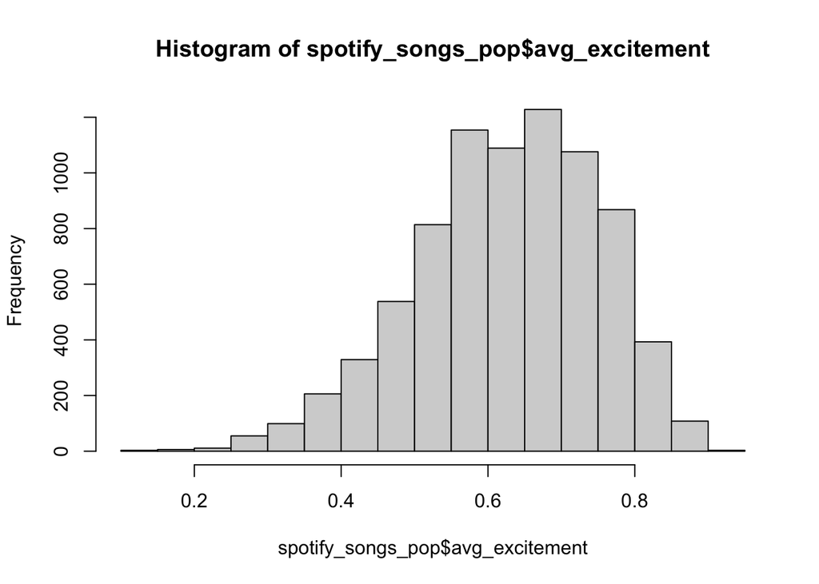

```r
# histogram
hist(spotify_songs_pop$avg_excitement)
```

## How to “apply” (columnwise)

```r
apply_cols <- apply(penguins[ , columns], MARGIN = 2, mean, na.rm = TRUE)
apply_cols
```

```
##    bill_length_mm     bill_depth_mm flipper_length_mm
##          43.92193          17.15117         200.91520
```

In order to run both mean and median on the selected columns we need to change the code a little. Within the apply function *we make a function* which finds the mean and median of x. X is the column to apply the functions too. The x in `function(x)` is just a reference we are using to refer to the column we are applying a function too, but you can use something else if you like, such as y.

```r
apply_cols <- apply(penguins[ , columns],
                    MARGIN = 2,
                    function(x) c(median(x, na.rm = TRUE),
                                  mean(x, na.rm = TRUE)))

apply_cols
```

```
##      bill_length_mm bill_depth_mm flipper_length_mm
## [1,]       44.45000      17.30000          197.0000
## [2,]       43.92193      17.15117          200.9152
```

To add rownames to the output we add them in after the c function, this makes the output clearer. To keep things simple we’ve called the rows median and mean. In R this concept is known as a *named vector*, to make a named vector you give the name then value `c(name = value)`.

```r
# named vector example
c(mean = 4.5, median = 4)
```

```
##   mean median
##    4.5    4.0
```

```r
# add rownames
apply_cols <- apply(penguins[ , columns],
                    MARGIN = 2,
                    function(x) c(median = median(x, na.rm = TRUE),
                                  mean = mean(x, na.rm = TRUE)))

apply_cols
```

```
##        bill_length_mm bill_depth_mm flipper_length_mm
## median       44.45000      17.30000          197.0000
## mean         43.92193      17.15117          200.9152
```

Again, there are other options that come with R by default in the colMeans and colSums functions.

```r
# mean values for selected columns
colMeans(penguins[, columns], na.rm = TRUE)
```

```
##    bill_length_mm     bill_depth_mm flipper_length_mm
##          43.92193          17.15117         200.91520
```

```r
# sum of values for selected columns
colSums(penguins[, columns], na.rm = TRUE)
```

```
##    bill_length_mm     bill_depth_mm flipper_length_mm
##           15021.3            5865.7           68713.0
```

Other calculations such as min, max, interquartile range are available with the `matrixStats` package.

### Columnwise apply exercise

We can pick up where we left off with our Spotify data! Here we will look at some statistics for chosen columns using columnwise apply.

1. Using `apply()` with a margin of 2 find the median, mean, standard deviation, inter quartile range, min, and max for the following columns in the `spotify_songs_pop` subset you made in the last exercise: track_popularity, avg_excitement, duration_mins
2. Review the output of your summary statistics
3. There are some really long songs in this data! Subset the data for songs with a duration over 8 minutes
4. There are also some duplicates which would be sensible to remove. Use `!duplicated(long_songs$track_id)` to filter out these cases
5. Use `table()` on the playlist_genre column to see what genre these long songs belong to.

```r
summary_cols <- c("track_popularity", "avg_excitement", "duration_mins")
# summary
popular_songs_summary <- apply(spotify_songs_pop[, summary_cols],
                         MARGIN = 2,
                         function(x) c(median = median(x, na.rm = TRUE),
                                      mean = mean(x, na.rm = TRUE),
                                      standard_deviation = sd(x, na.rm = TRUE),
                                      inter_quartile = IQR(x, na.rm = TRUE),
                                      min = min(x, na.rm =  TRUE),
                                      max = max(x, na.rm = TRUE)))
popular_songs_summary
```

```
##                    track_popularity avg_excitement duration_mins
## median                    72.000000      0.6350000     3.5434500
## mean                      73.058020      0.6265526     3.6562652
## standard_deviation         7.687646      0.1242630     0.8225048
## inter_quartile            11.000000      0.1740833     0.8939500
## min                       63.000000      0.1137667     1.1131000
## max                      100.000000      0.9153333     8.6301667
```

```r
long_songs <- subset(spotify_songs_pop, duration_mins > 8)
long_songs <- subset(long_songs, !duplicated(long_songs$track_id))
long_songs[, c("track_name", "track_artist")]
```

```
##                          track_name      track_artist
## 1278                        Mirrors Justin Timberlake
## 11769                  Stranglehold        Ted Nugent
## 11771       Kashmir - 2012 Remaster      Led Zeppelin
## 11915                  American Pie        Don McLean
## 12380                  American Pie        Don McLean
## 13035       Kashmir - 1990 Remaster      Led Zeppelin
## 13206 Stairway to Heaven - Remaster      Led Zeppelin
## 19382                   Darte Remix         Alex Rose
## 21328                    47 - Remix          Anuel AA
```

```r
table(long_songs$playlist_genre)
```

```
##
## latin   pop  rock
##     2     1     6
```

# lapply, sapply, and vapply

The main difference between apply and lapply is that the output is always a list with lapply. You also do not need to specify the margins with lapply as it assumes it will be working across columns.

```r
lapply_penguins <- lapply(penguins[ , columns], mean, na.rm = TRUE)
# print output
lapply_penguins
```

```
## $bill_length_mm
## [1] 43.92193
##
## $bill_depth_mm
## [1] 17.15117
##
## $flipper_length_mm
## [1] 200.9152
```

```r
# check the class
class(lapply_penguins)
```

```
## [1] "list"
```

We can do just as we did with apply and use `function(x)` to run mean and median over our selected columns. Each of the columns we run the functions on become named vectors within a list.

```r
lapply_penguins <- lapply(penguins[ , columns],
                          function(x) c(median = median(x, na.rm = TRUE),
                                        mean = mean(x, na.rm = TRUE)))

# print output
lapply_penguins
```

```
## $bill_length_mm
##   median     mean
## 44.45000 43.92193
##
## $bill_depth_mm
##   median     mean
## 17.30000 17.15117
##
## $flipper_length_mm
##   median     mean
## 197.0000 200.9152
```

```r
# access just flipper_length_mm
lapply_penguins$flipper_length_mm
```

```
##   median     mean
## 197.0000 200.9152
```

The sapply function is very similar to the lapply function but outputs a vector instead of a list. We can run the exact same code as we did with lapply, but our output will be slightly different.

First we can run just the mean on our selected columns. We can see from the the `str()` command that the output is a named number, which means a named vector.

```r
sapply_penguins <- sapply(penguins[, columns], mean, na.rm = TRUE)

sapply_penguins
```

```
##    bill_length_mm     bill_depth_mm flipper_length_mm
##          43.92193          17.15117         200.91520
```

```r
str(sapply_penguins)
```

```
##  Named num [1:3] 43.9 17.2 200.9
##  - attr(*, "names")= chr [1:3] "bill_length_mm" "bill_depth_mm" "flipper_length_mm"
```

Then we can run the mean and median on our columns.

```r
sapply_penguins <- sapply(penguins[ , columns],
                          function(x) c(median = median(x, na.rm = TRUE),
                                        mean = mean(x, na.rm = TRUE)))

sapply_penguins
```

```
##        bill_length_mm bill_depth_mm flipper_length_mm
## median       44.45000      17.30000          197.0000
## mean         43.92193      17.15117          200.9152
```

The vapply function is similar to sapply but stricter. You have to specify the expected output type. This is generally preferred as you have more control over the output produced. The syntax is slightly different: `vapply(data, function, output type, extra parameters)`. You have to specify the output type using the `FUN.VALUE` argument.

Here we know our output should be a double or numeric data type. Both work.

```r
vapply_penguins <- vapply(penguins[, columns], mean, FUN.VALUE = double(1), na.rm = T)
vapply_penguins
```

```
##    bill_length_mm     bill_depth_mm flipper_length_mm
##          43.92193          17.15117         200.91520
```

```r
vapply(penguins[, columns], mean, FUN.VALUE = numeric(1), na.rm = T)
```

```
##    bill_length_mm     bill_depth_mm flipper_length_mm
##          43.92193          17.15117         200.91520
```

## lapply, sapply, and vapply exercises

Using the `spotify_songs` data from earlier for the apply exercises:

1. Use `lapply()` to find the range for the acousticness, instrumentalness, and liveness columns
2. Use `sapply()` to find the range and quantiles for the same columns
3. We will convert all character data in the dataset to factors. Using `vapply()`, make a vector called *to_char* which contains true or false if a column is character or not. *hint: use is.character and FUN.VALUE logical*
4. Use `lapply()` to convert the columns in the `spotify_songs` data that are true to a factor *hint 1: use conditional indexing data[, vector == TRUE], hint 2: try as.factor*
5. Run `str()` on the `spotify_songs` data to see if your columns have changed to factor

```r
# your code here

# vector for column selection
my_cols <- c("acousticness", "instrumentalness", "liveness")
# lapply with range
lapply(spotify_songs[, my_cols], range, na.rm = TRUE)
```

```
## $acousticness
## [1] 0.000 0.994
##
## $instrumentalness
## [1] 0.000 0.994
##
## $liveness
## [1] 0.000 0.996
```

```r
# sapply with range and quantiles
sapply(spotify_songs[, my_cols],
       function(x) c(range = range(x, na.rm = TRUE),
                     quantiles = quantile(x, na.rm = TRUE)))
```

```
##                acousticness instrumentalness liveness
## range1               0.0000         0.00e+00   0.0000
## range2               0.9940         9.94e-01   0.9960
## quantiles.0%         0.0000         0.00e+00   0.0000
## quantiles.25%        0.0151         0.00e+00   0.0927
## quantiles.50%        0.0804         1.61e-05   0.1270
## quantiles.75%        0.2550         4.83e-03   0.2480
## quantiles.100%       0.9940         9.94e-01   0.9960
```

```r
# convert characters to factors
to_char <- vapply(spotify_songs, is.character, FUN.VALUE = logical(1))
spotify_songs[, to_char == TRUE] <- lapply(spotify_songs[, to_char == TRUE], as.factor)
str(spotify_songs)
```

```
## 'data.frame':    32833 obs. of  24 variables:
##  $ track_id                : Factor w/ 28356 levels "0017A6SJgTbfQVU2EtsPNo",..: 22912 2531 7160 25706 4705 26672 9521 22445 26146 5283 ...
##  $ track_name              : Factor w/ 23449 levels "_away","¡Corre!",..: 9042 12696 896 3057 18176 1921 13676 15603 20742 9637 ...
##  $ track_artist            : Factor w/ 10692 levels "_tag","-M-","!!!",..: 2818 6149 10610 9348 5497 2818 4971 8291 749 8534 ...
##  $ track_popularity        : int  66 67 70 60 69 67 62 69 68 67 ...
##  $ track_album_id          : Factor w/ 22545 levels "000f3dTtvpazVzv35NuZmn",..: 7684 17645 4144 4691 21907 8636 21592 17795 21050 13719 ...
##  $ track_album_name        : Factor w/ 19743 levels "_away","!","¡Hola!",..: 7760 10569 951 2836 15075 1853 11406 12985 17674 8047 ...
##  $ track_album_release_date: Factor w/ 4530 levels "1957-01-01","1957-03",..: 4316 4493 4336 4349 4221 4341 4356 4389 4316 4321 ...
##  $ playlist_name           : Factor w/ 449 levels "¡Viva Latino!",..: 309 309 309 309 309 309 309 309 309 309 ...
##  $ playlist_id             : Factor w/ 471 levels "0275i1VNfBnsNbPl0QIBpG",..: 237 237 237 237 237 237 237 237 237 237 ...
##  $ playlist_genre          : Factor w/ 6 levels "edm","latin",..: 3 3 3 3 3 3 3 3 3 3 ...
##  $ playlist_subgenre       : Factor w/ 24 levels "album rock","big room",..: 4 4 4 4 4 4 4 4 4 4 ...
##  $ danceability            : num  0.748 0.726 0.675 0.718 0.65 0.675 0.449 0.542 0.594 0.642 ...
##  $ energy                  : num  0.916 0.815 0.931 0.93 0.833 0.919 0.856 0.903 0.935 0.818 ...
##  $ key                     : int  6 11 1 7 1 8 5 4 8 2 ...
##  $ loudness                : num  -2.63 -4.97 -3.43 -3.78 -4.67 ...
##  $ mode                    : int  1 1 0 1 1 1 0 0 1 1 ...
##  $ speechiness             : num  0.0583 0.0373 0.0742 0.102 0.0359 0.127 0.0623 0.0434 0.0565 0.032 ...
##  $ acousticness            : num  0.102 0.0724 0.0794 0.0287 0.0803 0.0799 0.187 0.0335 0.0249 0.0567 ...
##  $ instrumentalness        : num  0.00 4.21e-03 2.33e-05 9.43e-06 0.00 0.00 0.00 4.83e-06 3.97e-06 0.00 ...
##  $ liveness                : num  0.0653 0.357 0.11 0.204 0.0833 0.143 0.176 0.111 0.637 0.0919 ...
##  $ valence                 : num  0.518 0.693 0.613 0.277 0.725 0.585 0.152 0.367 0.366 0.59 ...
##  $ tempo                   : num  122 100 124 122 124 ...
##  $ duration_ms             : int  194754 162600 176616 169093 189052 163049 187675 207619 193187 253040 ...
##  $ duration_mins           : num  3.25 2.71 2.94 2.82 3.15 ...
```

# Using lapply to load in lots of data

The list data type is very useful for efficient storage of data as it can hold any data type. For this reason lapply is a good choice for the bulk loading of data. If you have a lot of files or data from urls which you need to load, you can use lapply to load them all at once and store them into a list.

We have two examples below, one of loading *local* files from your computer, and one of loading data from urls.

To make the local data example reproducible, we will first create three data frames and save them as csv files in a folder called data. This should make a directory called data, then save all the files there. *note: this is purely for reproducibility and demonstration purposes, usually you will already have your files saved on your computer*

```r
# set up pathway
path <- "data/"

# make data directory if it doesn't already exist
if (dir.exists(path) == FALSE) {
  dir.create(path)
}
# set seed for reproducibility
set.seed(2021)

# vector for data frame names
df_names <- vector()
# empty list to put data frames
df_list <- list()

# make three data frames with random data and add to list
for (i in 1:3) {
  # create vectors
  x <- runif(5)
  y <- rnorm(5)
  z <- sample(1:10, 5)
  # add to a data frame
  df <- data.frame(x, y, z)
  # add df to a list
  df_list[[i]] <- df
  # make names and add to vector
  name <- paste0("df_", i)
  df_names[i] <- name
}

# add our data frame names to our list
names(df_list) <- df_names

# look at the created data frames
str(df_list)
```

```
## List of 3
##  $ df_1:'data.frame':    5 obs. of  3 variables:
##   ..$ x: num [1:5] 0.451 0.784 0.71 0.382 0.636
##   ..$ y: num [1:5] 0.528 -0.623 2.12 0.984 0.17
##   ..$ z: int [1:5] 7 9 10 4 3
##  $ df_2:'data.frame':    5 obs. of  3 variables:
##   ..$ x: num [1:5] 0.14 0.955 0.392 0.268 0.572
##   ..$ y: num [1:5] 1.354 1.177 0.896 1.578 1.294
##   ..$ z: int [1:5] 3 4 5 6 8
##  $ df_3:'data.frame':    5 obs. of  3 variables:
##   ..$ x: num [1:5] 0.173 0.847 0.426 0.957 0.135
##   ..$ y: num [1:5] 0.8199 -2.1276 0.9281 0.4055 0.0783
##   ..$ z: int [1:5] 2 1 8 9 6
```

```r
# use for loop to write the files
for (save_file in names(df_list)) {
  write.csv(df_list[[save_file]], file = paste0("data/", save_file, ".csv"))
}

# print the files in data directory to show files
list.files(path)
```

```
## [1] "df_1.csv" "df_2.csv" "df_3.csv"
```

Now we have made the files we can load them back in. To do so we set up the path which tells R where to look for the data. Then we use list.files to make a vector with the file names of the data we want to load. Finally, we use lapply to load in all the files. You can add names to the data frames after loading.

```r
# where you files are
path <- "data"

# use list files to find csv files from a directory
files <- list.files(path = path, pattern = ".csv", full.names = TRUE)

# print files
files
```

```
## [1] "data/df_1.csv" "data/df_2.csv" "data/df_3.csv"
```

```r
# load the files into a list
load_data <- lapply(files, read.csv)

# give names to the data frames you've loaded
names(load_data) <- c("data_1", "data_2", "data_3")

# see the data loaded
str(load_data)
```

```
## List of 3
##  $ data_1:'data.frame':  5 obs. of  4 variables:
##   ..$ X: int [1:5] 1 2 3 4 5
##   ..$ x: num [1:5] 0.451 0.784 0.71 0.382 0.636
##   ..$ y: num [1:5] 0.528 -0.623 2.12 0.984 0.17
##   ..$ z: int [1:5] 7 9 10 4 3
##  $ data_2:'data.frame':  5 obs. of  4 variables:
##   ..$ X: int [1:5] 1 2 3 4 5
##   ..$ x: num [1:5] 0.14 0.955 0.392 0.268 0.572
##   ..$ y: num [1:5] 1.354 1.177 0.896 1.578 1.294
##   ..$ z: int [1:5] 3 4 5 6 8
##  $ data_3:'data.frame':  5 obs. of  4 variables:
##   ..$ X: int [1:5] 1 2 3 4 5
##   ..$ x: num [1:5] 0.173 0.847 0.426 0.957 0.135
##   ..$ y: num [1:5] 0.8199 -2.1276 0.9281 0.4055 0.0783
##   ..$ z: int [1:5] 2 1 8 9 6
```

This process can also be done loading in data from the internet. Instead of having a list of files, we have a list of urls we want to load.

In this example we will load in datasets from Github urls. The urls come from the [tidytuesday Github repository](https://github.com/rfordatascience/tidytuesday). The datasets are Lemurs, Scooby Doo, and Star Trek computer commands.

```r
# make a vector of urls
urls <- c("https://raw.githubusercontent.com/rfordatascience/tidytuesday/master/data/2021/2021-08-24/lemur_data.csv",
          "https://raw.githubusercontent.com/rfordatascience/tidytuesday/master/data/2021/2021-07-13/scoobydoo.csv",
          "https://raw.githubusercontent.com/rfordatascience/tidytuesday/master/data/2021/2021-08-17/computer.csv")

# make a vector of names for the datasets
data_names <- c("lemurs", "Scooby_Doo", "Star_Trek")

# load in all the urls into a list
url_load <- lapply(urls, read.csv)

# add the names to the datasets
names(url_load) <- data_names
names(url_load)
```

```
## [1] "lemurs"     "Scooby_Doo" "Star_Trek"
```

```r
# view the scooby doo dataset
head(url_load$Scooby_Doo)
```

```
##   index                series_name network season                     title
## 1     1 Scooby Doo, Where Are You!     CBS      1 What a Night for a Knight
## 2     2 Scooby Doo, Where Are You!     CBS      1     A Clue for Scooby Doo
## 3     3 Scooby Doo, Where Are You!     CBS      1      Hassle in the Castle
## 4     4 Scooby Doo, Where Are You!     CBS      1    Mine Your Own Business
## 5     5 Scooby Doo, Where Are You!     CBS      1     Decoy for a Dognapper
## 6     6 Scooby Doo, Where Are You!     CBS      1    What the Hex Going On?
##   imdb engagement date_aired run_time    format            monster_name
## 1  8.1        556 1969-09-13       21 TV Series            Black Knight
## 2  8.1        479 1969-09-20       22 TV Series  Ghost of Cptn. Cuttler
## 3    8        455 1969-09-27       21 TV Series                 Phantom
## 4  7.8        426 1969-10-04       21 TV Series             Miner 49'er
## 5  7.5        391 1969-10-11       21 TV Series     Indian Witch Doctor
## 6  8.4        384 1969-10-18       21 TV Series Ghost of Elias Kingston
##   monster_gender     monster_type monster_subtype monster_species monster_real
```

[output cut: 90 more lines]

## Lapply loading data exercise

Using the examples above, load in the three datasets from urls listed below. Once loaded change the names of the data frames. Use `View()` to review your data once they are loaded and the names are changed.

The data is about tennis grand slams, and was from April 2019.

Urls:

- player date of birth (dob): “https://raw.githubusercontent.com/rfordatascience/tidytuesday/master/data/2019/2019-04-09/player_dob.csv”
- grand slams: “https://raw.githubusercontent.com/rfordatascience/tidytuesday/master/data/2019/2019-04-09/grand_slams.csv”
- grand slam timeline: “https://raw.githubusercontent.com/rfordatascience/tidytuesday/master/data/2019/2019-04-09/grand_slam_timeline.csv”

```r
# your code here
urls <- c("https://raw.githubusercontent.com/rfordatascience/tidytuesday/master/data/2019/2019-04-09/player_dob.csv", "https://raw.githubusercontent.com/rfordatascience/tidytuesday/master/data/2019/2019-04-09/grand_slams.csv", "https://raw.githubusercontent.com/rfordatascience/tidytuesday/master/data/2019/2019-04-09/grand_slam_timeline.csv")

df_names <- c("player_dob", "grand_slams", "grand_slam_timeline")

tennis_load <- lapply(urls, read.csv)

names(tennis_load) <- df_names

tail(tennis_load$player_dob)
```

```
##                      name      grand_slam date_of_birth date_of_first_title
## 100        Novak Djokovic Australian Open    1987-05-22          2008-01-28
## 101 Juan Martín del Potro         US Open    1988-09-23          2009-09-14
## 102           Andy Murray         US Open    1987-05-15          2012-09-10
## 103         Stan Wawrinka Australian Open    1985-03-28          2014-01-26
## 104           Marin Čilić         US Open    1988-09-28          2014-09-08
## 105        William Bowrey            <NA>    1943-12-25                <NA>
##       age
## 100  7556
## 101  7661
## 102  9250
## 103 10531
## 104  9476
## 105    NA
```

```r
tail(tennis_load$grand_slams)
```

```
##     year      grand_slam           name rolling_win_count tournament_date
## 411 2017         us_open   Rafael Nadal                16      2017-09-09
## 412 2018 australian_open  Roger Federer                20      2018-01-10
## 413 2018     french_open   Rafael Nadal                17      2018-06-09
## 414 2018       wimbledon Novak Djokovic                13      2018-07-14
## 415 2018         us_open Novak Djokovic                14      2018-09-09
## 416 2019 australian_open Novak Djokovic                15      2019-01-10
##     gender
## 411   Male
## 412   Male
## 413   Male
## 414   Male
## 415   Male
## 416   Male
```

```r
tail(tennis_load$grand_slam_timeline)
```

```
##                      player year      tournament         outcome gender
## 12600         Kei Nishikori 2019 Australian Open Quarterfinalist   Male
## 12601 Juan Martín del Potro 2019 Australian Open          Absent   Male
## 12602          Milos Raonic 2019 Australian Open Quarterfinalist   Male
## 12603         Dominic Thiem 2019 Australian Open       2nd Round   Male
## 12604    Jo-Wilfried Tsonga 2019 Australian Open       2nd Round   Male
## 12605         Stan Wawrinka 2019 Australian Open       2nd Round   Male
```

# tapply

The tapply function is quite different to the other apply functions in that it performs aggregations. To use tapply we need a factor (or dummy variable) to break up our average calculations by. We can use the `str()` function to see if we already have factors in our data.

```r
str(penguins)
```

```
## tibble [344 × 9] (S3: tbl_df/tbl/data.frame)
##  $ species          : Factor w/ 3 levels "Adelie","Chinstrap",..: 1 1 1 1 1 1 1 1 1 1 ...
##  $ island           : Factor w/ 3 levels "Biscoe","Dream",..: 3 3 3 3 3 3 3 3 3 3 ...
##  $ bill_length_mm   : num [1:344] 39.1 39.5 40.3 NA 36.7 39.3 38.9 39.2 34.1 42 ...
##  $ bill_depth_mm    : num [1:344] 18.7 17.4 18 NA 19.3 20.6 17.8 19.6 18.1 20.2 ...
##  $ flipper_length_mm: int [1:344] 181 186 195 NA 193 190 181 195 193 190 ...
##  $ body_mass_g      : int [1:344] 3750 3800 3250 NA 3450 3650 3625 4675 3475 4250 ...
##  $ sex              : Factor w/ 2 levels "female","male": 2 1 1 NA 1 2 1 2 NA NA ...
##  $ year             : int [1:344] 2007 2007 2007 2007 2007 2007 2007 2007 2007 2007 ...
##  $ bill_flip_avg    : num [1:344] 79.6 81 84.4 NaN 83 ...
```

The species, island, and sex columns are factors so we can use one of these to break up our calculation. For this example we will just species with bill_lenght_mm.

```r
# method 1
tapply(penguins$bill_length_mm, factor(penguins$species), mean, na.rm = TRUE)
```

```
##    Adelie Chinstrap    Gentoo
##  38.79139  48.83382  47.50488
```

```r
# method 2
penguins$species <- as.factor(penguins$species)

tapply_penguins <- tapply(penguins$bill_length_mm, penguins$species, mean, na.rm = TRUE)
tapply_penguins
```

```
##    Adelie Chinstrap    Gentoo
##  38.79139  48.83382  47.50488
```

As you can see you get a named vector back with the mean bill_length_mm for each species of penguin.

If you want to add another factor, such as what island the penguins live on we put the factors in a list within the tapply function.

```r
# make sure island is a factor
penguins$island <- as.factor(penguins$island)
# adding multiple factors
tapply(penguins$bill_depth_mm,
       list(penguins$species, penguins$island),
       mean, na.rm = TRUE)
```

```
##             Biscoe    Dream Torgersen
## Adelie    18.37045 18.25179  18.42941
## Chinstrap       NA 18.42059        NA
## Gentoo    14.98211       NA        NA
```

We can also use tapply to do counts of factors or string data by using `length()` as our function. However, this is equivalent to the `table()` function which involves less typing.

```r
# count species vs sex
tapply(penguins$species, list(penguins$species, penguins$sex), length)
```

```
##           female male
## Adelie        73   73
## Chinstrap     34   34
## Gentoo        58   61
```

```r
# table version
table(penguins$species, penguins$sex)
```

```
##
##             female male
##   Adelie        73   73
##   Chinstrap     34   34
##   Gentoo        58   61
```

The main downside of tapply is that is only allows you to work on one vector (or column) of data at a time. There are several other options to allow you to do this but they are beyond the scope of this tutorial; the three main alternatives are the `aggregate()` function that comes with the base version of R, `group_by()` and `summarise()` that come with the dplyr package, and the data.table package.

## tapply exercises

Using the `spotify_songs` data we used in previous exercises and using tapply, work out the following:

- Find the median duration per track_artist
- Find the median duration per track_artist and playlist genre

We will filter the data to only look at a selection of artists: Led Zeppelin, Queen, The Beatles, Fleetwood Mac, Madonna, Beyoncé, Taylor Swift, and Ed Sheeran.

1. First, make the track_artist column a character data type and save the result back to the `spotify_songs` data
2. Make a vector of the selected artists specified above
3. Subset the data to only include the selected artists
4. Using `tapply()` find the median duration per track_artist
5. Using `tapply()` find the median duration per track_artist and playlist genre
6. Use the `table()` function to count how many times each artist appears in the dataset

```r
# your code here
spotify_songs <- transform(spotify_songs, track_artist = as.character(track_artist))

artists <- c("Led Zeppelin", "Queen", "The Beatles", "Fleetwood Mac",
             "Madonna", "Beyoncé", "Taylor Swift", "Ed Sheeran")

filtered_spotify <- subset(spotify_songs, track_artist %in% artists)

tapply(filtered_spotify$duration_mins,
       filtered_spotify$track_artist,
       median, na.rm = TRUE)
```

```
##       Beyoncé    Ed Sheeran Fleetwood Mac  Led Zeppelin       Madonna
##      3.797550      3.464900      3.726883      4.923117      4.826000
##         Queen  Taylor Swift   The Beatles
##      3.567333      3.653333      3.636450
```

```r
tapply(filtered_spotify$duration_mins,
       list(filtered_spotify$track_artist, filtered_spotify$playlist_genre),
       median, na.rm = TRUE)
```

```
##                    edm    latin      pop      r&b      rap     rock
## Beyoncé             NA 3.577883 3.933550 3.708817 3.312667       NA
## Ed Sheeran    3.376433 3.665783 3.464900 3.665783       NA       NA
## Fleetwood Mac       NA       NA       NA       NA       NA 3.726883
## Led Zeppelin        NA       NA 2.437500       NA       NA 5.244000
## Madonna             NA 5.508767 4.418892       NA       NA       NA
## Queen               NA       NA 4.654550       NA       NA 3.567333
## Taylor Swift  3.592775 3.668000 3.592108 3.653333       NA       NA
## The Beatles         NA       NA       NA       NA       NA 3.636450
```

```r
table(filtered_spotify$track_artist)
```

```
##
##       Beyoncé    Ed Sheeran Fleetwood Mac  Led Zeppelin       Madonna
##            25            69            28            35             5
##         Queen  Taylor Swift   The Beatles
##           136            27            19
```

```r
# option to use with to save using $
with(
  filtered_spotify,
  tapply(duration_mins, track_artist, median, na.rm = TRUE)
)
```

```
##       Beyoncé    Ed Sheeran Fleetwood Mac  Led Zeppelin       Madonna
##      3.797550      3.464900      3.726883      4.923117      4.826000
##         Queen  Taylor Swift   The Beatles
##      3.567333      3.653333      3.636450
```

```r
with(
  filtered_spotify,
  tapply(duration_mins, list(track_artist, playlist_genre), median, na.rm = TRUE)
)
```

```
##                    edm    latin      pop      r&b      rap     rock
## Beyoncé             NA 3.577883 3.933550 3.708817 3.312667       NA
## Ed Sheeran    3.376433 3.665783 3.464900 3.665783       NA       NA
## Fleetwood Mac       NA       NA       NA       NA       NA 3.726883
## Led Zeppelin        NA       NA 2.437500       NA       NA 5.244000
## Madonna             NA 5.508767 4.418892       NA       NA       NA
## Queen               NA       NA 4.654550       NA       NA 3.567333
## Taylor Swift  3.592775 3.668000 3.592108 3.653333       NA       NA
## The Beatles         NA       NA       NA       NA       NA 3.636450
```

# Introduction to the map family of functions

The map family of functions work in very much the same way as the apply functions, however they are in some ways simpler. You select the map function based on the output you want, for example, if you want character you use `map_chr()` or if you want a data frame you use `map_df()`. The `map()` function can be used to apply a function to each element of a vector, list, or data frame column. The output is returned as a list.

To use map, we first have to install the `purrr` library. This is part of the *tidyverse* ecosystem of packages which are covered in the R Data Wrangling and R Data Visualisation series.

```r
install.packages("purrr")
```

Find a quick example below. In this, map() takes two arguments: the first is the list to be mapped over, and the second is the function to be applied to each element of the list (in this case, `mean()`).

```r
library(purrr)

columns <- c("bill_length_mm", "bill_depth_mm", "flipper_length_mm", "body_mass_g")

map(penguins[, columns], mean, na.rm = TRUE)
```

```
## $bill_length_mm
## [1] 43.92193
##
## $bill_depth_mm
## [1] 17.15117
##
## $flipper_length_mm
## [1] 200.9152
##
## $body_mass_g
## [1] 4201.754
```

How easy was that? How does this technique compare this to the efficiency of loops?

`map()` works a bit like `lapply()`. What if we wanted to have our output be a vector? Well this is where `map()` gets really cool. To have the output be a vector of the double data type we use `map_dlb()`. There is also the option to use `map_vec()` which outputs a vector in a similar way to `sapply()`, in that it picks a data type for you.

```r
map_dbl(penguins[, columns], mean, na.rm = TRUE)
```

```
##    bill_length_mm     bill_depth_mm flipper_length_mm       body_mass_g
##          43.92193          17.15117         200.91520        4201.75439
```

```r
map_vec(penguins[, columns], mean, na.rm = TRUE)
```

```
##    bill_length_mm     bill_depth_mm flipper_length_mm       body_mass_g
##          43.92193          17.15117         200.91520        4201.75439
```

Just like apply functions we can define shorthand functions. Here we use this to calculate the mean as well as median for each column.

```r
map(penguins[, columns],
    function(x) c(mean = mean(x, na.rm = TRUE),
                  median = median(x, na.rm = TRUE)))
```

```
## $bill_length_mm
##     mean   median
## 43.92193 44.45000
##
## $bill_depth_mm
##     mean   median
## 17.15117 17.30000
##
## $flipper_length_mm
##     mean   median
## 200.9152 197.0000
##
## $body_mass_g
##     mean   median
## 4201.754 4050.000
```

A nice feature of the map functions is the ability to use a `~` instead of the `function()` call, making things a bit neater. `~` defines an anonymous function, with `.` being the place holder for the argument, in the same way that `function(x) x` works.

Look at this code and the code chunk above. Can you spot the two differences between them?

```r
map(penguins[, columns],
    ~ c(mean = mean(.x, na.rm = TRUE),
                  median = median(.x, na.rm = TRUE)))
```

```
## $bill_length_mm
##     mean   median
## 43.92193 44.45000
##
## $bill_depth_mm
##     mean   median
## 17.15117 17.30000
##
## $flipper_length_mm
##     mean   median
## 200.9152 197.0000
##
## $body_mass_g
##     mean   median
## 4201.754 4050.000
```

If we wanted our output as a data.frame we would use `map()` wrapped in a `data.frame()` function. Why is there no data frame option? There used to be but because of inconsistency issues it was removed.

```r
data.frame(
  map(penguins[, columns],
      ~ c(mean = mean(.x, na.rm = TRUE),
                 median = median(.x, na.rm = TRUE)))
  )
```

```
##        bill_length_mm bill_depth_mm flipper_length_mm body_mass_g
## mean         43.92193      17.15117          200.9152    4201.754
## median       44.45000      17.30000          197.0000    4050.000
```

The key advantage of using the map family of functions over apply is the consistency and flexibility. They are just as powerful, but you have more control, plus they work well within the *tidyverse ecosystem* (see data wrangling and data visualisation workshops).

The purrr reference page can also be helpful, each function often has useful examples: https://purrr.tidyverse.org/reference/index.html

*note: you might have noticed we did not perform the rowwise operation with map. This is because the tidyverse way of doing this is using the rowwise function from the dplyr package - https://dplyr.tidyverse.org/articles/rowwise.html*

## Introduction to the map family of functions exercise

In this exercise we are going to use the map family of functions to count how often the word love is used in the track names, album names, and playlist names.

Here is the code we can use to find the number of times *love* is used in the track name column. Your job is to use this code to count how often love is used in each of the columns `track_name`,`track_album_name`, and `playlist_name` using `map()`.

*note: this code uses grepl to patten match. Use ?grepl to look it up*

```r
sum(
  grepl(
    "love", spotify_songs[, "track_name"],
    ignore.case = TRUE
  )
)
```

```
## [1] 1281
```

1. First, make a vector with the column names of the columns we want to use: `track_name`,`track_album_name`, and `playlist_name`
2. Next, use `map()` to find the number of times love was mentioned in each of your columns
3. Lets try out a different map variant. Use the same code but use `map_dbl()` instead. What is the difference in the output?
4. Finally, using the code you’ve used in part 2 or 3, transform your output to a data frame

```r
# your code here

# pick out cols with text data
name_cols <- c("track_name", "track_album_name", "playlist_name")

# total songs, albums and playlists that contain word 'love'
map(spotify_songs[, name_cols],
    function(x) sum(grepl("love", x, ignore.case = TRUE)))
```

```
## $track_name
## [1] 1281
##
## $track_album_name
## [1] 898
##
## $playlist_name
## [1] 355
```

```r
# alt using ~
map(spotify_songs[, name_cols],
    ~ sum(grepl("love", .x, ignore.case = TRUE)))
```

```
## $track_name
## [1] 1281
##
## $track_album_name
## [1] 898
##
## $playlist_name
## [1] 355
```

```r
map_dbl(spotify_songs[, name_cols],
    function(x) sum(grepl("love", x, ignore.case = TRUE)))
```

```
##       track_name track_album_name    playlist_name
##             1281              898              355
```

```r
data.frame(
  map(spotify_songs[, name_cols],
    function(x) sum(grepl("love", x, ignore.case = TRUE)))
)
```

```
##   track_name track_album_name playlist_name
## 1       1281              898           355
```

```r
# n songs
length(unique(spotify_songs$track_id))
```

```
## [1] 28356
```

# Loop vs. Apply: what’s your verdict?

In general, it is recommended to use apply or map functions wherever possible because they are faster and easier to read than for loops. However, there may be situations where a for loop is more appropriate, such as when you need more control over the iteration process or when you are working with complex data structures that cannot be easily processed by apply functions.

# Some useful resources

These are two useful guides/tutorials on the purrr library, where the map family of functions come from. In this workshop we only covered the basics of map but there is lots more to dive into!

https://www.rebeccabarter.com/blog/2019-08-19_purrr

https://jennybc.github.io/purrr-tutorial

# Final task - Please give us your individual feedback!

We would be grateful if you could take a minute before the end of the workshop so we can get your feedback!

https://lse.eu.qualtrics.com/jfe/form/SV_6eSrOVWuit28qcS?coursename=R%Intermediate%2:%Functional%programming&topic=R&prog=DS&version=23-24&link=https://lsecloud.sharepoint.com/:f:/s/TEAM_APD-DSL-Digital-Skills-Trainers/EouhwWBxe6lApboHwWHQBMAB53jnX0xFdIlOZ7kb4ovC3A?e=sbvEZ3

The solutions we be available from a link at the end of the survey.

# Individual coding challenge

For the individual coding challenge we are going to use apply/map functions to automate a small analysis pipeline using simple linear regressions, bringing together ideas and concepts of what we have covered so far.

This challenge is similar to what we did with for loops, but this time we are using functional loops.

Some code has been provided to help you along the way!

## Part 1 - Using apply/map to load in data

We have an Excel file, called `top_shows.xlsx`, which has our data stored in multiple sheets. The column names are the same for each sheet. Each sheet represents a different Broadway show.

1. Load in the readxl library
2. Make a variable called `path` which is the pathway to your `top_shows.xlsx` file
3. Make a variable called `sheets`, using the `excel_sheets()` function, from readxl, with your path variable to extract the sheet names from your file.
4. Using `map()` or an `lapply()` load in all the data from all sheets, store the resulting list as `broadway` or similar
5. Now your data is loaded into your list, you can add names to those datasets. Using the names function add the names from your `sheets` variable to the datasets in your list. *hint: this is the same as assigning column names*
6. Finally, as all our column names are the same we can bind these datasets together. Using list_rbind`()` from the `purrr` library, combine the loaded datasets into a data frame and save the result as `top_broadway` or similar.

```r
# load readxl and purrr
library(readxl)
library(purrr)

# path to xlsx file
path <- "top_shows.xlsx"

# extract sheet information
sheets <- readxl::excel_sheets(path)

# use map to load in data
broadway <- map(sheets, ~ read_excel(path, sheet = .x))
# lapply(sheets, function(x) read_excel(path, sheet = x))

# add sheet names to datasets
names(broadway) <- sheets

# combine the datasets using list_rbind from purrr
top_broadway <- purrr::list_rbind(broadway)
```

## Part 2 - Review data

1. make a vector called `selected_cols` with the columns `weekly_gross_overall`, `avg_ticket_price`, `seats_sold`, and `performances`.
2. Filter your top_broadway data to include only your selected columns. Assign this filtered data to `top_broadway_filt`
3. Use `summary()` to review the summary statistics of your filtered data
4. Now we will make some plots comparing weekly_gross_overall to our independent variables using `map()` or `lapply()`.
   - First define `par(mfrow = c(2,2))` so we can view them all plots once.
   - Now use `map()` or `lapply()` to plot your variables

*Hint 1:* plot will take a filtered dataset. If we gave the `plot()` function this code: `top_broadway_filt[, c(2, 1)]` what would it plot? *Hint 2:* think of your code like a for loop, we want your map/apply function to loop through different indices for our plotting code. E.g. `map(seq(2, 4, by = 1), function)`

```r
# vector with columns of interest
selected_cols <- c("weekly_gross_overall", "avg_ticket_price",
                   "seats_sold", "performances")

# filtered data by columns
top_broadway_filt <- top_broadway[, selected_cols]

# summary statistics
summary(top_broadway_filt)
```

```
##  weekly_gross_overall avg_ticket_price   seats_sold     performances
##  Min.   : 2933761     Min.   :  0.00   Min.   :    0   Min.   :0.000
##  1st Qu.:10331272     1st Qu.: 53.19   1st Qu.: 8668   1st Qu.:8.000
##  Median :15002509     Median : 68.25   Median :11160   Median :8.000
##  Mean   :16804115     Mean   : 74.13   Mean   :10795   Mean   :7.928
##  3rd Qu.:22305181     3rd Qu.: 84.63   3rd Qu.:13096   3rd Qu.:8.000
##  Max.   :57807272     Max.   :242.15   Max.   :16319   Max.   :9.000
```

```r
# make scatter plots
par(mfrow = c(2,2))

# use map to make scatter plots
map(seq(2, 4, by = 1), ~ plot(top_broadway_filt[, c(.x, 1)]))
```

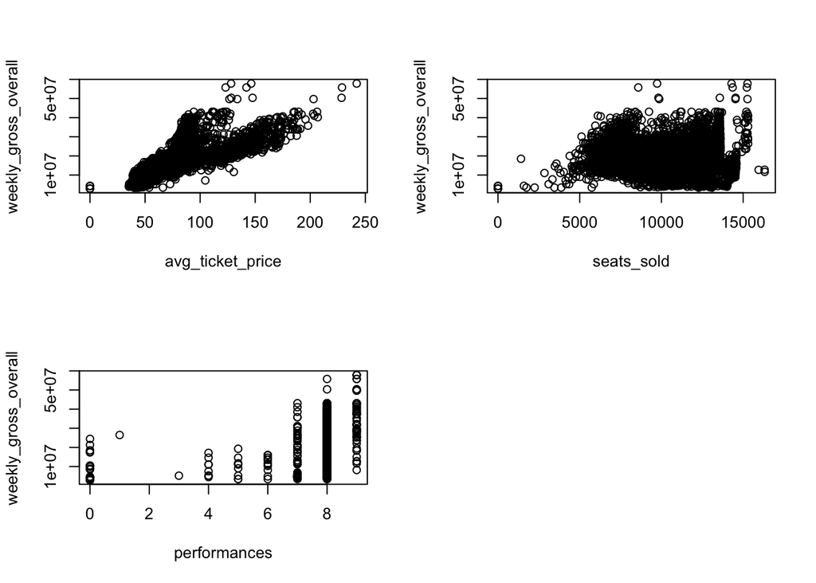

```r
#lapply(seq(2, 4, by = 1), function(x) plot(top_broadway_filt[, c(x, 1)]))
```

## Part 3 - Analysis using regressions with some different variables

To finish off this challenge we will use map/apply to iteratively add variables to a regression, allowing you to see the effect each addition has on the model.

Here we are going to start with a simple linear regression, then build up to a multiple linear regression (still only 3 predictor variables). We will be using our prepared data from earlier `top_broadway_filt`.

To keep things a bit simpler we have provided two functions to use with map and apply. Have a look at the R Intermediate 3 workshop that introduces functions to start using your own functions. The first function is adapted from this article: https://statisticsglobe.com/r-multiple-regressions-in-for-loop.

1. Use `map()` or `lapply()` and the `model_loop` function to build three models, that add a new column from our `top_broadway_filt` data on each loop. Assign the result to `model_summaries`.
2. Check your results by printing model_summaries
3. Cool! We just run several regressions. We can now review the results. Use `map()` or `lapply()` with the `adjust_r` function to review your R squared for each model in model_summaries. Your output should look something like *Model 1 has adjusted R Squared of 0.603*
4. Finally, use the functions tidy and glance from broom, with map or apply to get summaries of your models!

```r
# load required packages
library(purrr)
library(broom)

# model function
model_loop <- function(x) {
  predictors <- colnames(top_broadway_filt)[2:x]
  summary(
    lm(
      weekly_gross_overall ~ .,
      data = top_broadway_filt[, c("weekly_gross_overall", predictors)]
    )
  )
}

#adj r function
adjust_r <- function(x) {
  r_sq <- round(model_summaries[[x]][["adj.r.squared"]], 3)
  paste0("Model ", x, " has adjusted R Squared of ", r_sq)
}

# your code here

# loop over columns of Broadway to do build regression models
model_summaries <- map(2:ncol(top_broadway_filt), model_loop)

model_summaries
```

```
## [[1]]
##
## Call:
## lm(formula = weekly_gross_overall ~ ., data = top_broadway_filt[,
##     c("weekly_gross_overall", predictors)])
##
## Residuals:
##       Min        1Q    Median        3Q       Max
## -18258468  -3851660   -925579   2751777  28498245
##
## Coefficients:
##                  Estimate Std. Error t value Pr(>|t|)
## (Intercept)       -372968     210348  -1.773   0.0763 .
## avg_ticket_price   231710       2634  87.951   <2e-16 ***
## ---
## Signif. codes:  0 '***' 0.001 '**' 0.01 '*' 0.05 '.' 0.1 ' ' 1
##
## Residual standard error: 5580000 on 5099 degrees of freedom
## Multiple R-squared:  0.6027, Adjusted R-squared:  0.6026
## F-statistic:  7735 on 1 and 5099 DF,  p-value: < 2.2e-16
##
##
## [[2]]
##
## Call:
## lm(formula = weekly_gross_overall ~ ., data = top_broadway_filt[,
##     c("weekly_gross_overall", predictors)])
##
## Residuals:
##       Min        1Q    Median        3Q       Max
## -23677564  -2854241   -691109   2226399  26579737
##
## Coefficients:
##                    Estimate Std. Error t value Pr(>|t|)
## (Intercept)      8915242.20  325391.38   27.40   <2e-16 ***
## avg_ticket_price  248173.65    2411.34  102.92   <2e-16 ***
## seats_sold          -973.48      27.77  -35.05   <2e-16 ***
## ---
## Signif. codes:  0 '***' 0.001 '**' 0.01 '*' 0.05 '.' 0.1 ' ' 1
##
```

[output cut: 12 more lines]

```
##       Min        1Q    Median        3Q       Max
## -24055889  -2903412   -738478   2191598  25513186
##
## Coefficients:
##                    Estimate Std. Error t value Pr(>|t|)
## (Intercept)      -176367.48  869558.57  -0.203    0.839
## avg_ticket_price  245705.11    2392.25 102.709   <2e-16 ***
## seats_sold         -1028.26      27.87 -36.901   <2e-16 ***
## performances     1244379.29  110586.38  11.253   <2e-16 ***
## ---
## Signif. codes:  0 '***' 0.001 '**' 0.01 '*' 0.05 '.' 0.1 ' ' 1
##
## Residual standard error: 4949000 on 5097 degrees of freedom
## Multiple R-squared:  0.6876, Adjusted R-squared:  0.6874
## F-statistic:  3740 on 3 and 5097 DF,  p-value: < 2.2e-16
```

```r
# using map to look at adjusted R Square of each model
map(seq_along(model_summaries), adjust_r)
```

```
## [[1]]
## [1] "Model 1 has adjusted R Squared of 0.603"
##
## [[2]]
## [1] "Model 2 has adjusted R Squared of 0.68"
##
## [[3]]
## [1] "Model 3 has adjusted R Squared of 0.687"
```

```r
# using broom tidy
tidy_model <- map(model_summaries, tidy)
tidy_model
```

```
## [[1]]
## # A tibble: 2 × 5
##   term             estimate std.error statistic p.value
##   <chr>               <dbl>     <dbl>     <dbl>   <dbl>
## 1 (Intercept)      -372968.   210348.     -1.77  0.0763
## 2 avg_ticket_price  231710.     2635.     88.0   0
##
## [[2]]
## # A tibble: 3 × 5
##   term             estimate std.error statistic   p.value
##   <chr>               <dbl>     <dbl>     <dbl>     <dbl>
## 1 (Intercept)      8915242.  325391.       27.4 2.66e-154
## 2 avg_ticket_price  248174.    2411.      103.  0
## 3 seats_sold          -973.      27.8     -35.1 2.41e-241
##
## [[3]]
## # A tibble: 4 × 5
##   term             estimate std.error statistic   p.value
##   <chr>               <dbl>     <dbl>     <dbl>     <dbl>
## 1 (Intercept)      -176367.  869559.     -0.203 8.39e-  1
## 2 avg_ticket_price  245705.    2392.    103.    0
## 3 seats_sold         -1028.      27.9   -36.9   2.12e-264
## 4 performances     1244379.  110586.     11.3   4.94e- 29
```

```r
# using broom glance
model_glance <- map(model_summaries, glance)
model_glance
```

```
## [[1]]
## # A tibble: 1 × 8
##   r.squared adj.r.squared    sigma statistic p.value    df df.residual  nobs
##       <dbl>         <dbl>    <dbl>     <dbl>   <dbl> <dbl>       <int> <dbl>
## 1     0.603         0.603 5579694.     7735.       0     1        5099  5101
##
## [[2]]
## # A tibble: 1 × 8
##   r.squared adj.r.squared    sigma statistic p.value    df df.residual  nobs
##       <dbl>         <dbl>    <dbl>     <dbl>   <dbl> <dbl>       <int> <dbl>
## 1     0.680         0.680 5009192.     5413.       0     2        5098  5101
##
## [[3]]
## # A tibble: 1 × 8
##   r.squared adj.r.squared    sigma statistic p.value    df df.residual  nobs
##       <dbl>         <dbl>    <dbl>     <dbl>   <dbl> <dbl>       <int> <dbl>
## 1     0.688         0.687 4948594.     3740.       0     3        5097  5101
```